# MT01

## 1. Process the data (4 points)

```r
library("faraway")
data("pima")
```

Initially process the data by discovering and labeling the missing data with NA; and converting categorical variable(s) to proper factors with meaningful labels.

1. 1. For the variables, diastolic, glucose, triceps, insulin, bmi, the researchers have coded missing data with 0-values, convert these 0-values to NA. Show R code.

```r
#To replace the possible missing values with NA

head(pima)
```

```
##   pregnant glucose diastolic triceps insulin  bmi diabetes age test
## 1        6     148        72      35       0 33.6    0.627  50    1
## 2        1      85        66      29       0 26.6    0.351  31    0
## 3        8     183        64       0       0 23.3    0.672  32    1
## 4        1      89        66      23      94 28.1    0.167  21    0
## 5        0     137        40      35     168 43.1    2.288  33    1
## 6        5     116        74       0       0 25.6    0.201  30    0
```

```r
pima$glucose[pima$glucose==0]<- NA
pima$diastolic[pima$diastolic==0]<- NA
pima$triceps[pima$triceps==0]<- NA
pima$insulin[pima$insulin==0]<- NA
pima$bmi[pima$bmi==0]<- NA
```

2. Convert test to factor type variable. Show R code.

```r
#Convert categorical variables to factor
pima$test<-factor(pima$test)
```

3. Convert levels of test to “negative” and “positive”. Show R code.

```r
levels(pima$test) <- c("Negative", "Positive")
```

4. Verify that variables insulin and triceps appear to have the most missing values. Use subset() to remove these variables from the original dataset. Then remove any rows with missing values. How many cases remain?

```r
#Total number of rows
pima_glucose<- pima[is.na(pima$glucose),]
pima_diastolic<- pima[is.na(pima$diastolic),]
pima_triceps<- pima[is.na(pima$triceps),]
pima_Insulin<- pima[is.na(pima$insulin),]
pima_bmi <- pima[is.na(pima$bmi),]
dim(pima)
```

```
## [1] 768   9
```

```r
dim(pima_glucose)
```

```
## [1] 5 9
```

```r
dim(pima_diastolic)
```

```
## [1] 35  9
```

```r
dim(pima_triceps)
```

```
## [1] 227   9
```

```r
dim(pima_Insulin)
```

```
## [1] 374   9
```

```r
dim(pima_bmi)
```

```
## [1] 11  9
```

We can infer that variables insulin and triceps have most numbers of missing values. For Insulin : Total Missing values = 374 For Triceps: Total Missing Values = 227

```r
# Use subset() to remove these variables from the original dataset.
pima <- subset(pima, select = c("pregnant","glucose","diastolic","bmi","diabetes","age","test"))
```

```r
#Remove any rows with missing values.
pima<-na.omit(pima)
str(pima)
```

```
## 'data.frame':    724 obs. of  7 variables:
##  $ pregnant : int  6 1 8 1 0 5 3 2 4 10 ...
##  $ glucose  : int  148 85 183 89 137 116 78 197 110 168 ...
##  $ diastolic: int  72 66 64 66 40 74 50 70 92 74 ...
##  $ bmi      : num  33.6 26.6 23.3 28.1 43.1 25.6 31 30.5 37.6 38 ...
##  $ diabetes : num  0.627 0.351 0.672 0.167 2.288 ...
##  $ age      : int  50 31 32 21 33 30 26 53 30 34 ...
##  $ test     : Factor w/ 2 levels "Negative","Positive": 2 1 2 1 2 1 2 2 1 2 ...
##  - attr(*, "na.action")=Class 'omit'  Named int [1:44] 8 10 16 50 61 76 79 82 146 173 ...
##   .. ..- attr(*, "names")= chr [1:44] "8" "10" "16" "50" ...
```

After Omitting missing values and excluding insulin and triceps variables we get 724 observation in 7 variables .

# 2 Scatterplot matrix (4 points)

1. Obtain and show the scatterplot matrix of all the remaining variables while viewing the diabetes variable as the output variable.

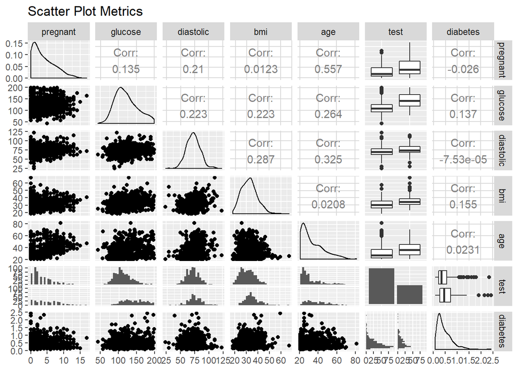

```r
#pairs(~ pregnant+glucose+diastolic+bmi+age+test+diabetes, data=pima)
#Unlike pairs(), ggpairs() works with non-numeric
#predictors in addition to numeric ones.
# Hence we use ggpairs for the output.
library("GGally")
(ggpair<-ggpairs(data=pima,columns=c("pregnant","glucose","diastolic","bmi","age","test","diabetes"),title="Scatter Plot Metrics"))
```

2. Identify any potential predictors for diabetes. Explain your answer.

```r
#To find potential predictors we use correlation

cor(pima$pregnant,pima$diabetes)
```

```
## [1] -0.02599607
```

```r
cor(pima$glucose,pima$diabetes)
```

```
## [1] 0.1366297
```

```r
cor(pima$diastolic,pima$diabetes)
```

```
## [1] -7.527687e-05
```

```r
cor(pima$bmi,pima$diabetes)
```

```
## [1] 0.1548582
```

```r
cor(pima$age,pima$diabetes)
```

```
## [1] 0.0230981
```

Looking at the plot we can see that many numerical variable are relatively correlated with diabetes response like bmi and glucose hence making them potential predictors.

However, diastolic, pregnant , age variables have negligible correlation co-efficient and hence are weakly related with response of diabetes hence we can ingnore these variables.

3. Are they any potential outliers? Yes, on observing the box plot we can see that negative tests has a lot of outliers thus reducing the significance of this factor.

Also, the variables having very less pearson correlation coefficient like diastolic, pregnant and age have lots of potential outliers which would not help build a good regression model.

d.Identify any skewed variables and recommend proper transformations, “log()” or “sqrt()”, if any. Explain your answer.

```r
#To check for skewness of variable.
library(e1071)
skewness(pima$pregnant)
```

```
## [1] 0.9013027
```

```r
skewness(pima$glucose)
```

```
## [1] 0.524935
```

```r
skewness(pima$diastolic)
```

```
## [1] 0.1370595
```

```r
skewness(pima$bmi)
```

```
## [1] 0.5957094
```

```r
skewness(pima$diabetes)
```

```
## [1] 1.913578
```

```r
skewness(pima$age)
```

```
## [1] 1.08402
```

```r
summary(pima)
```

```
##     pregnant         glucose         diastolic          bmi
##  Min.   : 0.000   Min.   : 44.00   Min.   : 24.0   Min.   :18.20
##  1st Qu.: 1.000   1st Qu.: 99.75   1st Qu.: 64.0   1st Qu.:27.50
##  Median : 3.000   Median :117.00   Median : 72.0   Median :32.40
##  Mean   : 3.866   Mean   :121.88   Mean   : 72.4   Mean   :32.47
##  3rd Qu.: 6.000   3rd Qu.:142.00   3rd Qu.: 80.0   3rd Qu.:36.60
##  Max.   :17.000   Max.   :199.00   Max.   :122.0   Max.   :67.10
##     diabetes           age              test
##  Min.   :0.0780   Min.   :21.00   Negative:475
##  1st Qu.:0.2450   1st Qu.:24.00   Positive:249
##  Median :0.3790   Median :29.00
##  Mean   :0.4748   Mean   :33.35
##  3rd Qu.:0.6275   3rd Qu.:41.00
##  Max.   :2.4200   Max.   :81.00
```

All the variables are right skewed (mean is greater than median) as seen using skewness function(). Being right skewed , all the variable are having positive skewness.Hence, we can use the log tranformation due to 2 reasons: 1. Logarithmic tranformations are relative strong tranformations compared to sqrt function and helps in smoothening of normal distribution curve. 2. All the data are positive numbers so we need not consider log(0) or log(-#)

We can also verify the same thing by plotting a scatterplot of diabetes response with log and sqrt tranformation.

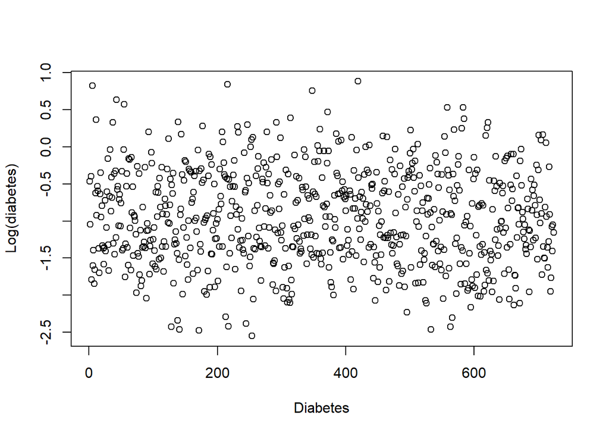

```r
log.y<-log(pima$diabetes)
plot(log.y,xlab="Diabetes",ylab="Log(diabetes)")
```

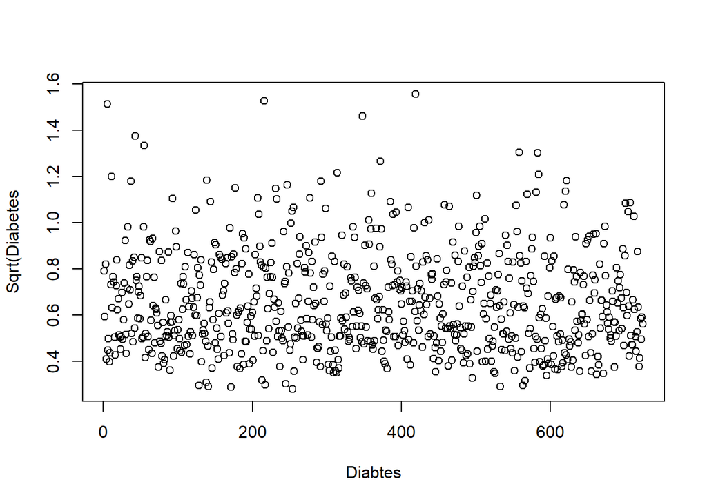

```r
sqrt.y<-sqrt(pima$diabetes)
plot(sqrt.y,xlab="Diabtes",ylab="Sqrt(Diabetes")
```

We can observe that log function has much closer scatter points which makes it a recommended tranformation ahead of sqrt function.

# 3Residual plots comparing two models (9 points)

1. Fit a linear model for diabetes using test, pregnant, glucose, and bmi as predictors. Call this model g. Show your R code.

```r
g<-lm(diabetes~test+pregnant+glucose+bmi,data = pima)
summary(g)
```

```
##
## Call:
## lm(formula = diabetes ~ test + pregnant + glucose + bmi, data = pima)
##
## Residuals:
##      Min       1Q   Median       3Q      Max
## -0.52191 -0.22592 -0.09188  0.15397  1.82626
##
## Coefficients:
##                Estimate Std. Error t value Pr(>|t|)
## (Intercept)   0.2381852  0.0752895   3.164  0.00162 **
## testPositive  0.1006256  0.0304286   3.307  0.00099 ***
## pregnant     -0.0065882  0.0036926  -1.784  0.07481 .
## glucose       0.0005709  0.0004521   1.263  0.20712
## bmi           0.0048623  0.0018481   2.631  0.00870 **
## ---
## Signif. codes:  0 '***' 0.001 '**' 0.01 '*' 0.05 '.' 0.1 ' ' 1
##
## Residual standard error: 0.3246 on 719 degrees of freedom
## Multiple R-squared:  0.05118,    Adjusted R-squared:  0.0459
## F-statistic: 9.696 on 4 and 719 DF,  p-value: 1.217e-07
```

b.Obtain and show plots of the g-residuals against each of the numeric predictors and against the fitted values.

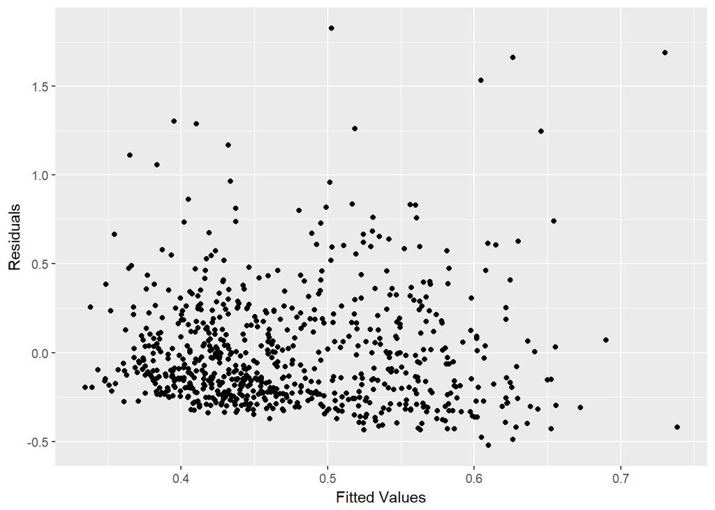

```r
library(ggplot2)
ggplot(g, aes(.fitted, .resid)) +
  geom_point() +
  labs(x="Fitted Values",y="Residuals")
```

```r
  ggtitle("Residual Plot")
```

```
## $title
## [1] "Residual Plot"
##
## $subtitle
## NULL
##
## attr(,"class")
## [1] "labels"
```

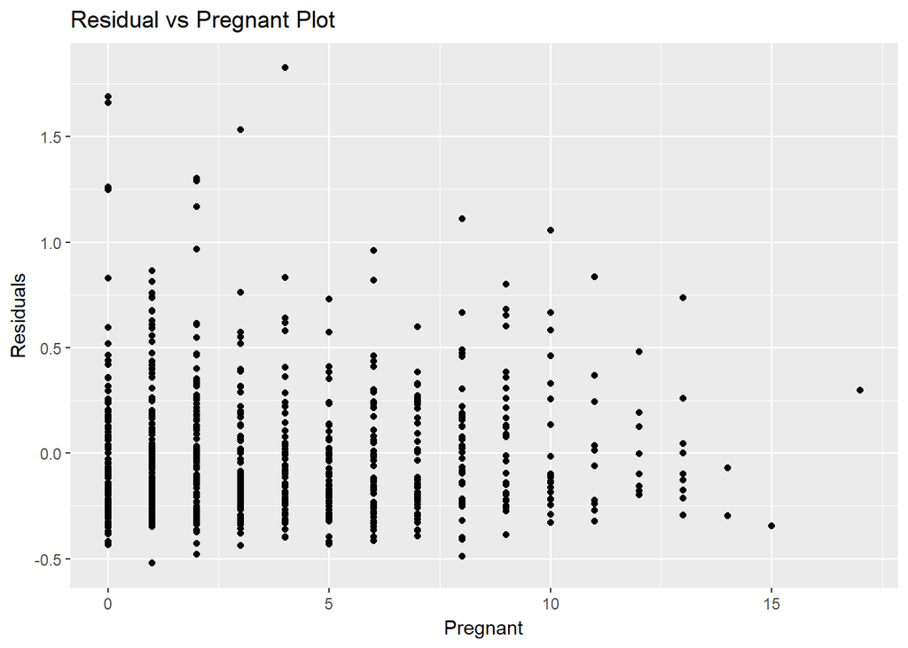

```r
  ggplot(g, aes(pima$pregnant, .resid)) +
    geom_point() +
    labs(x="Pregnant",y="Residuals")+
    ggtitle("Residual vs Pregnant Plot")
```

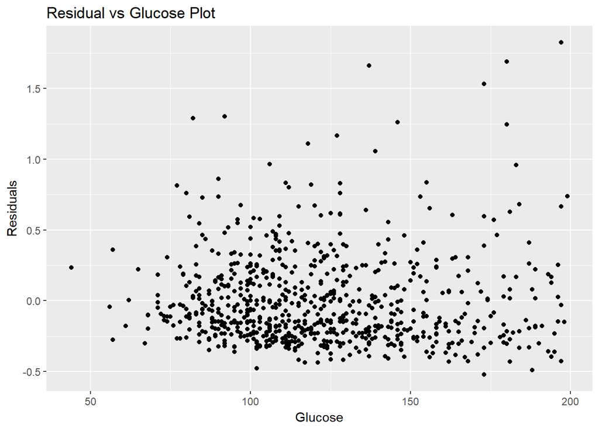

```r
  ggplot(g, aes(pima$glucose, .resid)) +
    geom_point() +
    labs(x="Glucose",y="Residuals")+
    ggtitle("Residual vs Glucose Plot")
```

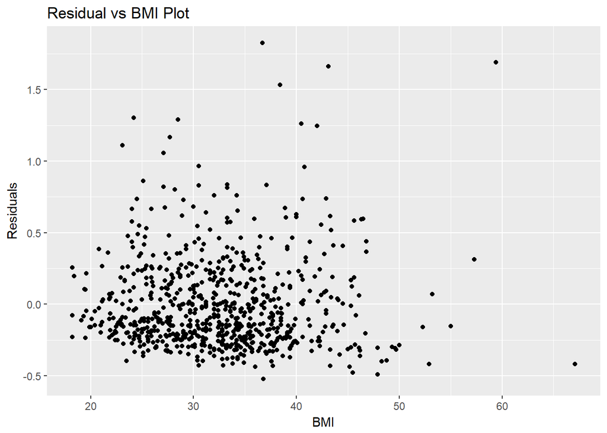

```r
  ggplot(g, aes(pima$bmi, .resid)) +
    geom_point() +
    labs(x="BMI",y="Residuals")+
    ggtitle("Residual vs BMI Plot")
```

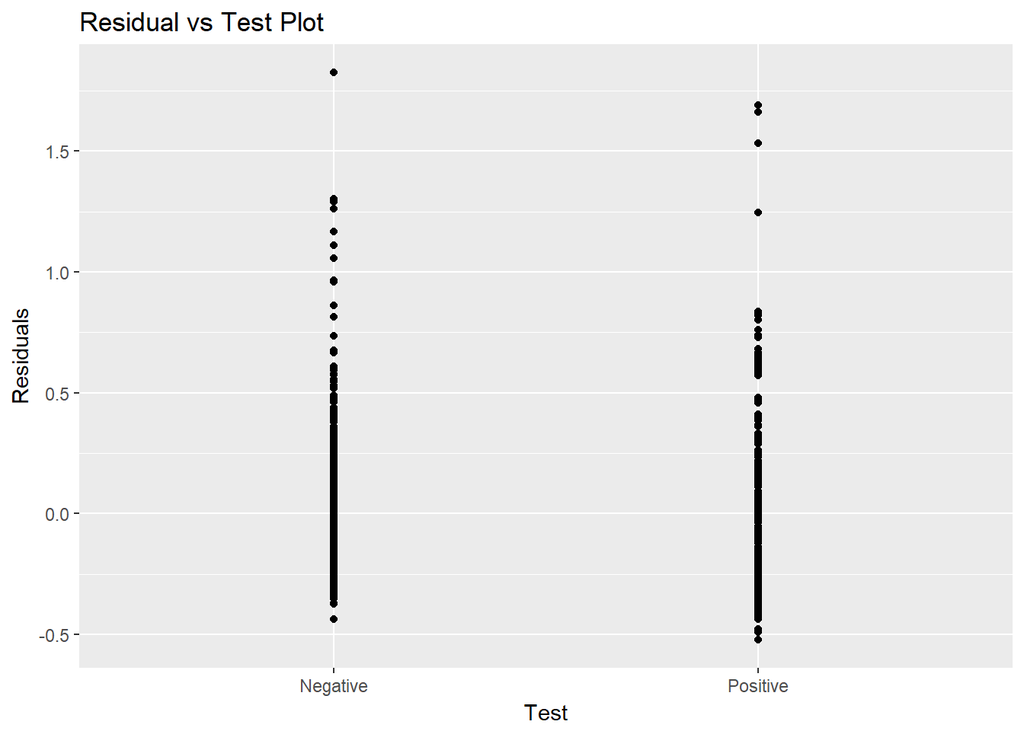

```r
  ggplot(g, aes(pima$test, .resid)) +
    geom_point() +
    labs(x="Test",y="Residuals")+
    ggtitle("Residual vs Test Plot")
```

3. Now fit a linear model for log(diabetes) using test, pregnant, glucose, and bmi as predictors. Call this model g1. Show your R code.

```r
g1<- lm(log(diabetes)~test+pregnant+glucose+bmi,data = pima)
```

4. Obtain and show plots of the g1-residuals against each of the numeric predictors and against the fitted values

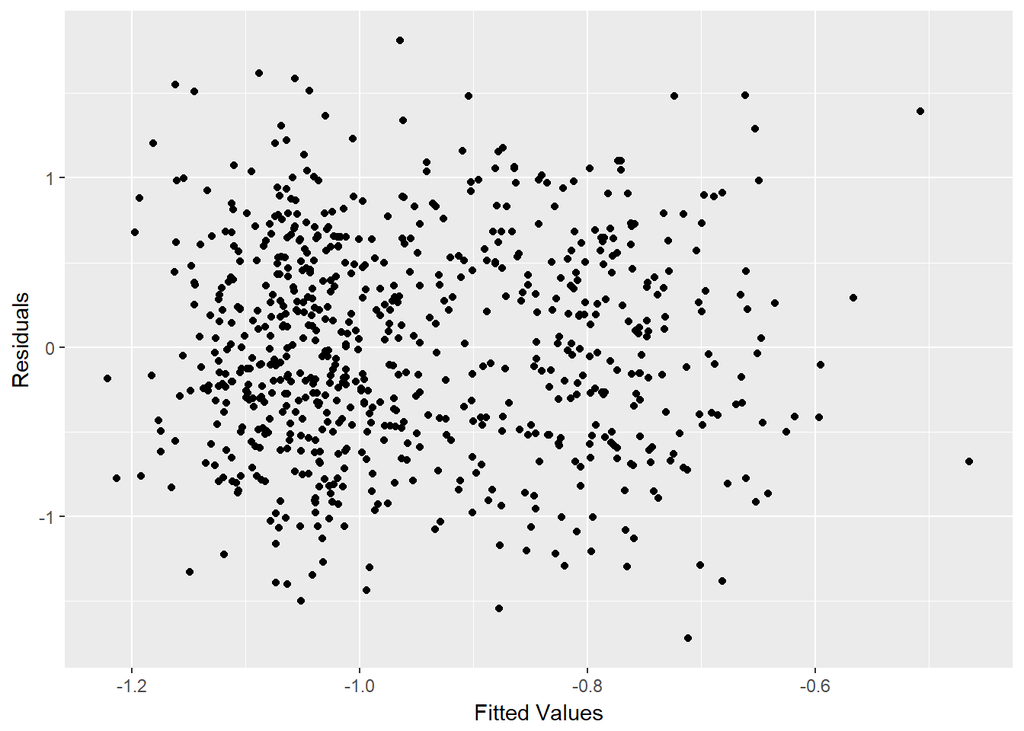

```r
ggplot(g1, aes(.fitted, .resid)) +
  geom_point() +
  labs(x="Fitted Values",y="Residuals")
```

```r
  ggtitle("Residual Plot for Log(Diabetes)")
```

```
## $title
## [1] "Residual Plot for Log(Diabetes)"
##
## $subtitle
## NULL
##
## attr(,"class")
## [1] "labels"
```

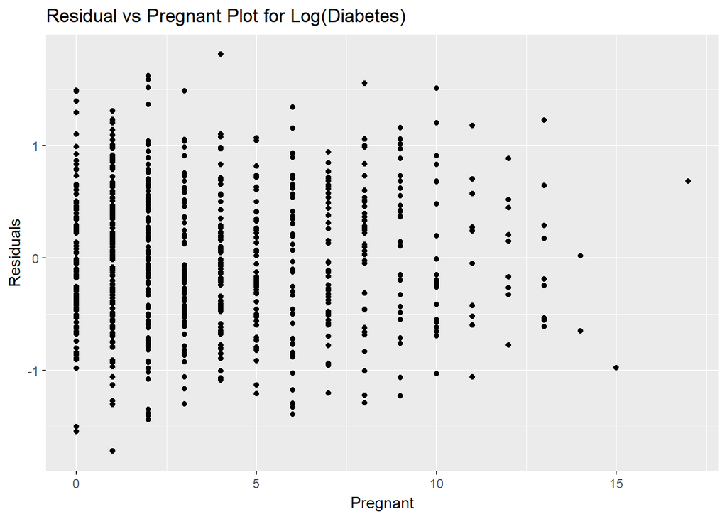

```r
ggplot(g1, aes(pima$pregnant, .resid)) +
  geom_point() +
  labs(x="Pregnant",y="Residuals")+
  ggtitle("Residual vs Pregnant Plot for Log(Diabetes)")
```

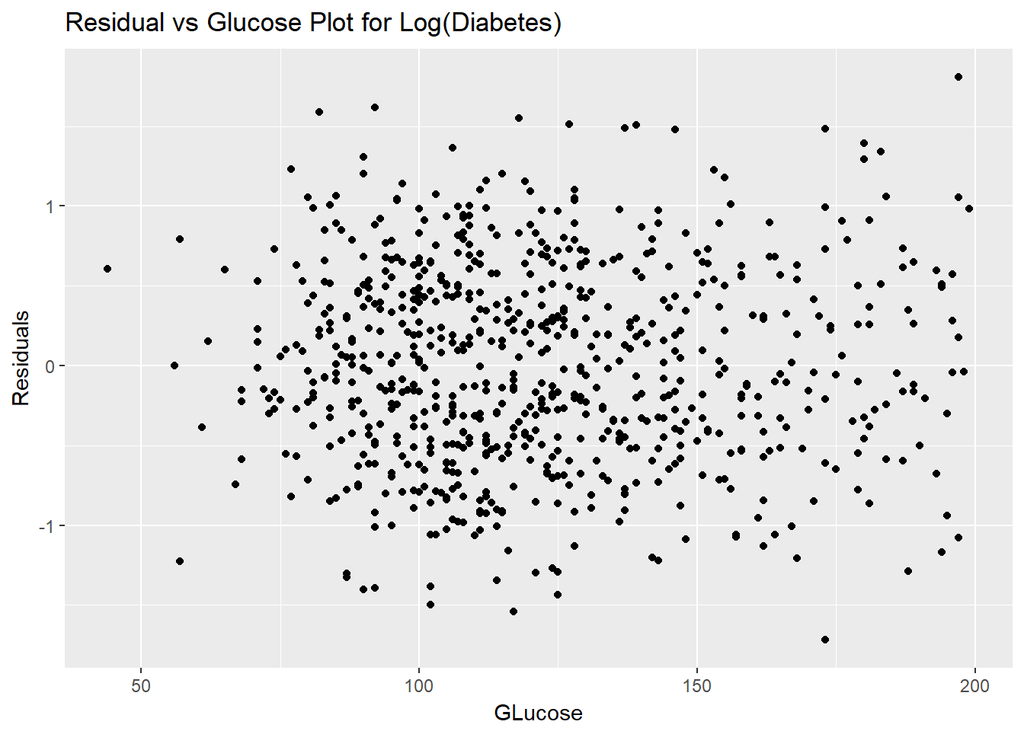

```r
ggplot(g1, aes(pima$glucose, .resid)) +
  geom_point() +
  labs(x="GLucose",y="Residuals")+
  ggtitle("Residual vs Glucose Plot for Log(Diabetes)")
```

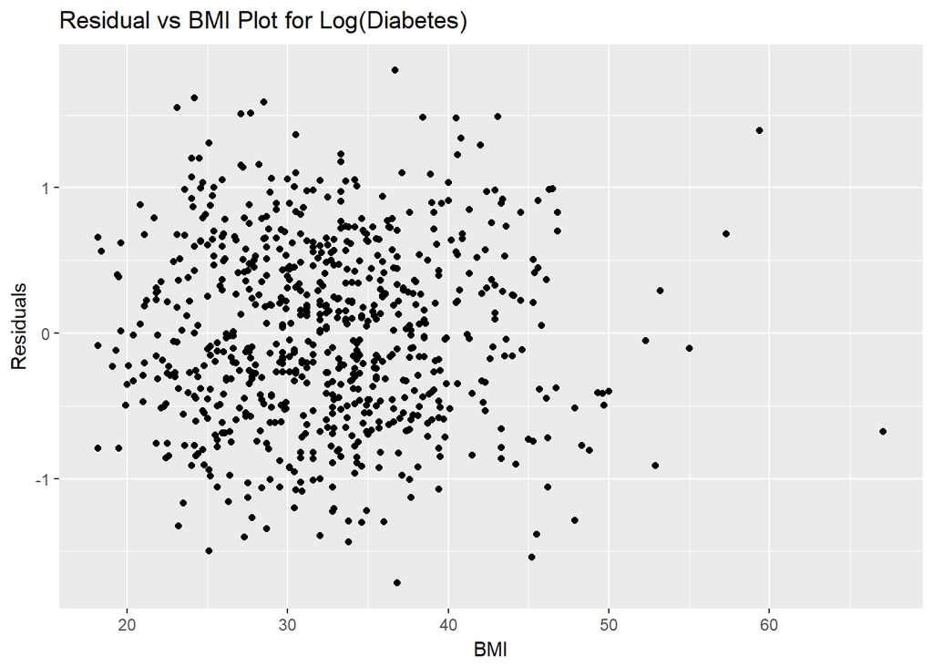

```r
ggplot(g1, aes(pima$bmi, .resid)) +
  geom_point() +
  labs(x="BMI",y="Residuals")+
  ggtitle("Residual vs BMI Plot for Log(Diabetes)")
```

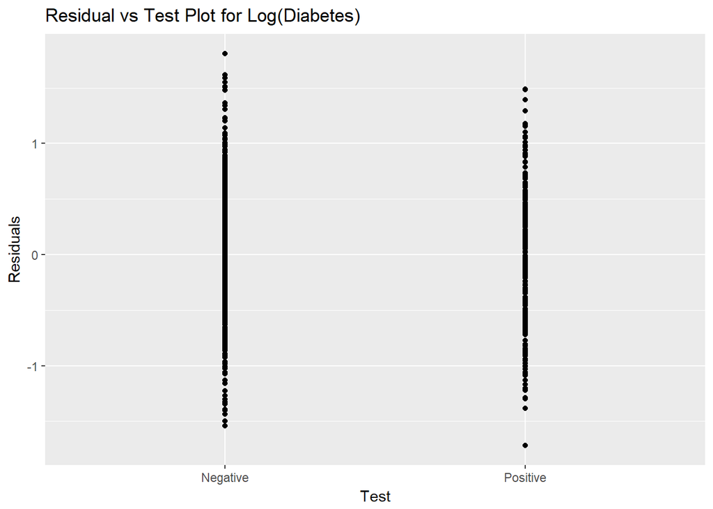

```r
ggplot(g1, aes(pima$test, .resid)) +
  geom_point() +
  labs(x="Test",y="Residuals")+
  ggtitle("Residual vs Test Plot for Log(Diabetes)")
```

5. Now visually compare all the residual plots from the two models g and g1. Do they explain why it is a good idea to take the logarithm before fitting the data? Explain your answer.

After visually comparing all the residual plots we can infer that the scattering effect is less for all the plots having log transformations. Following are the pont for making this conclusion:

1.The residuals have a skewed distribution in Residual vs Fitted Values plot. The purpose of a transformation is to obtain residuals that are approximately symmetrically distributed around zero which we can see for the log tranformation. 2.The spread of the residuals changes systematically with the values of the dependent variable (“heteroscedasticity”). The purpose of the log transformation is to remove that systematic change in spread, achieving approximate “homoscedasticity.” 3.To linearize a relationship as can be seen in the plots of residuals with predictors. 4.The total number of outlier in all the plot for logorthmic model is relatively less as compared to normal model henc simplifying the number and complexity of interaction terms.

6. Obtain and show the boxplots of the g-residuals versus test. Does the plot reveal any outliers?

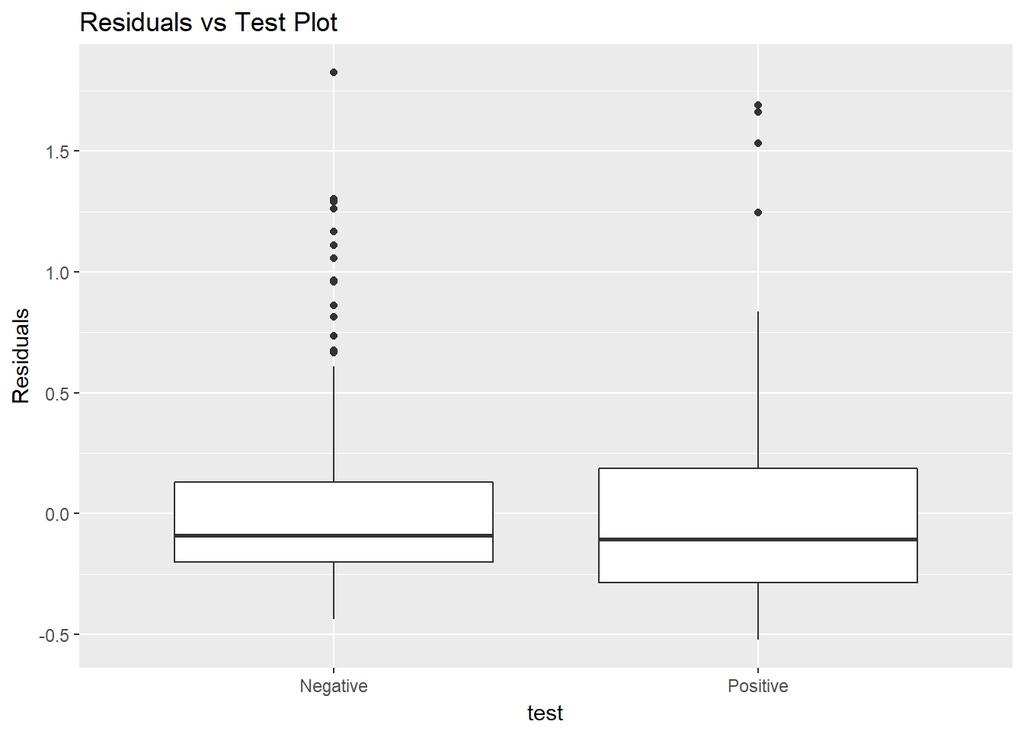

```r
(plot1 <- qplot(test, g$resid, geom = "boxplot", data=pima)+labs(y="Residuals")+ggtitle("Residuals vs Test Plot"))
```

The Box Plot for Test factor variable reveals a lot of outliers.

1. For Negative test , the total outliers are around 11.
2. For positve test, the total number of outliers are 4.
7. 7. Obtain and show the boxplots of the g1-residuals versus test. Does the plot reveal any outliers?

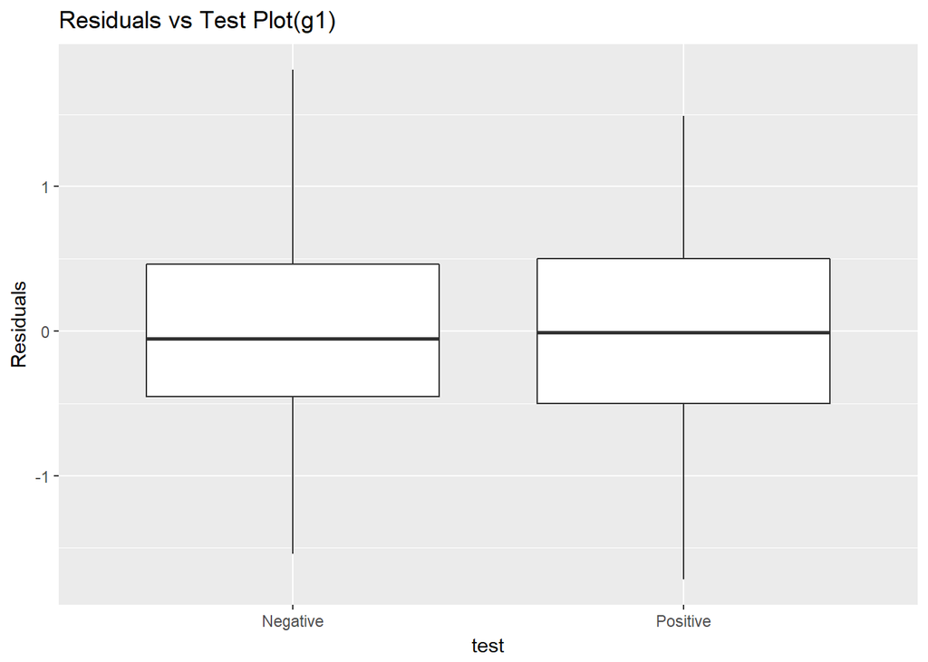

```r
(plot1 <- qplot(test, g1$resid, geom = "boxplot", data=pima)+labs(y="Residuals")+ggtitle("Residuals vs Test Plot(g1)"))
```

The plot does not reveal any outliers for both negative and positive test(Better Model).

8. Scale the g-residuals with z-score, then obtain and show the Normal QQ-Plot. Does the plot indicate the residuals are normal or not normal? Explain your answer.

```r
a<-g$residuals
mean(a)
```

```
## [1] -4.450526e-19
```

```r
sd(a)
```

```
## [1] 0.3236994
```

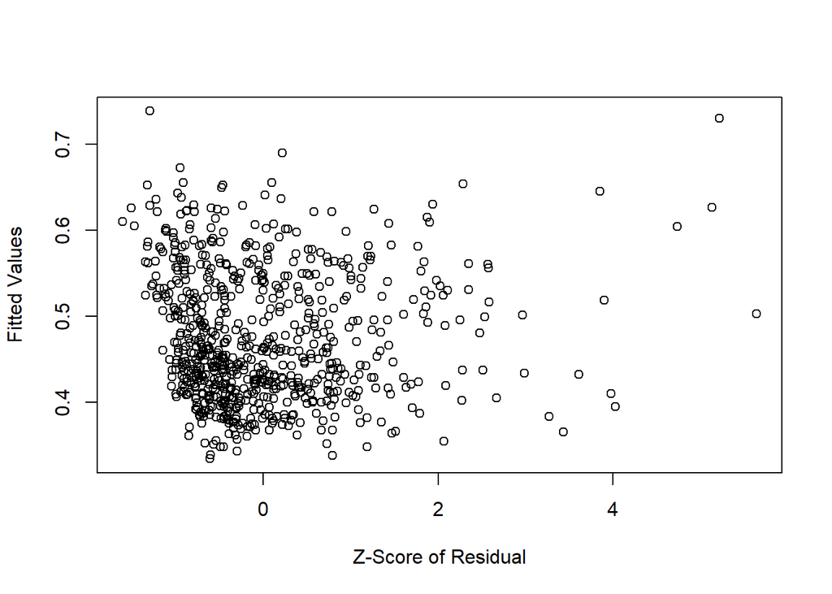

```r
#Scaling of Z-score with g-residuals
zscore<- (a-mean(a))/sd(a)
b<-plot(zscore, g$fitted.values, xlab = "Z-Score of Residual", ylab = "Fitted Values")
```

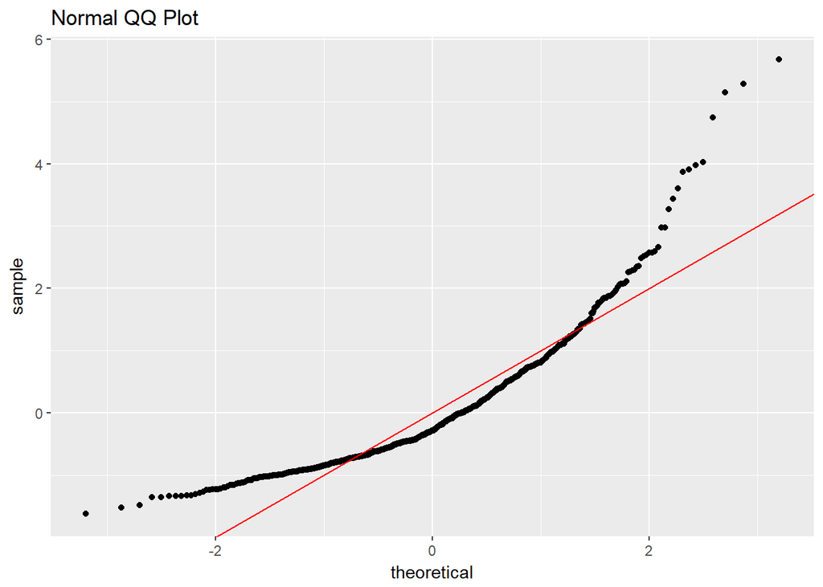

```r
#Normal QQ Plot
mod <- fortify(g)
(plot3 <- qplot(sample =.stdresid, data = mod, geom = "qq")+ geom_abline(col="red")+ggtitle("Normal QQ Plot"))
```

The plot clearly indicates that the residuals are not normal as they are very far away from the regression line.

1. Scale the g1-residuals with z-score, then obtain and show the Normal QQ-Plot. Does the plot indicate the residuals are normal or not normal? Explain your answer.

```r
a1<-g1$residuals
mean(a1)
```

```
## [1] 9.500359e-18
```

```r
sd(a1)
```

```
## [1] 0.6273721
```

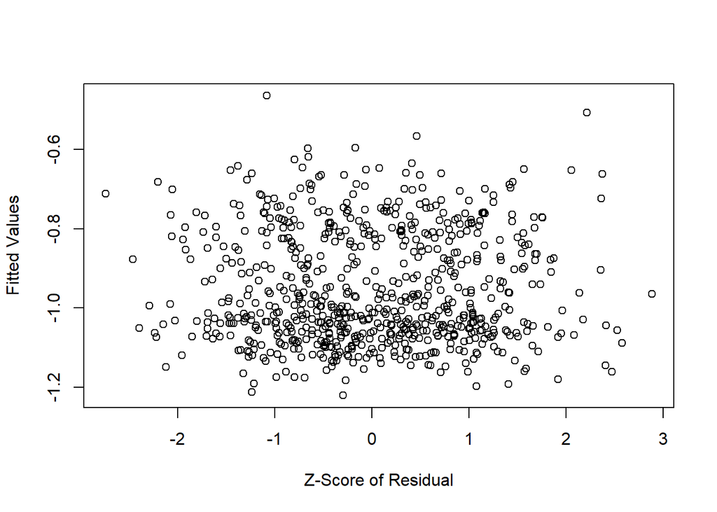

```r
#Scaling of Z-score with g-residuals
zscore1<- (a1-mean(a1))/sd(a1)
b1<-plot(zscore1, g1$fitted.values, xlab = "Z-Score of Residual", ylab = "Fitted Values")
```

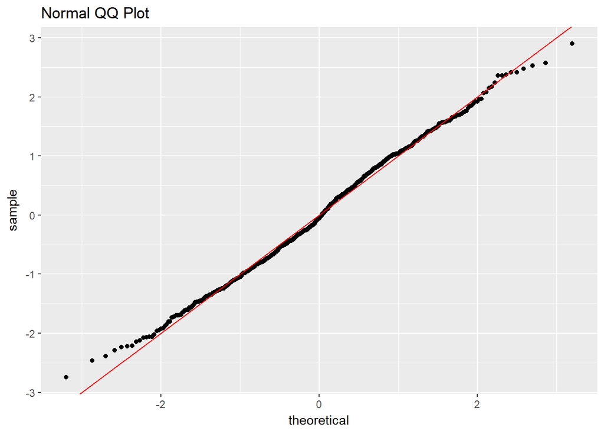

```r
#Normal QQ Plot
mod <- fortify(g1)
(plot3 <- qplot(sample =.stdresid, data = g1, geom = "qq")+ geom_abline(col="red")+ggtitle("Normal QQ Plot"))
```

The Normal QQ plot displayed has residuals closely packed to the regression line hence we can infer that residuals are normally distributed.

# 4. Interpreting coefficients (3 points)

1. Interpret the value of the coefficient for test in the g1-model (not the g-model) used in question 3.

```r
coef(g1)
```

```
##   (Intercept)  testPositive      pregnant       glucose           bmi
## -1.3037626387  0.2246113909 -0.0125759611  0.0004214602  0.0083489383
```

```r
summary(g1)
```

```
##
## Call:
## lm(formula = log(diabetes) ~ test + pregnant + glucose + bmi,
##     data = pima)
##
## Residuals:
##      Min       1Q   Median       3Q      Max
## -1.71884 -0.46622 -0.03373  0.47313  1.81007
##
## Coefficients:
##                Estimate Std. Error t value Pr(>|t|)
## (Intercept)  -1.3037626  0.1459210  -8.935  < 2e-16 ***
## testPositive  0.2246114  0.0589747   3.809 0.000152 ***
## pregnant     -0.0125760  0.0071567  -1.757 0.079303 .
## glucose       0.0004215  0.0008762   0.481 0.630675
## bmi           0.0083489  0.0035818   2.331 0.020033 *
## ---
## Signif. codes:  0 '***' 0.001 '**' 0.01 '*' 0.05 '.' 0.1 ' ' 1
##
## Residual standard error: 0.6291 on 719 degrees of freedom
## Multiple R-squared:  0.04787,    Adjusted R-squared:  0.04258
## F-statistic: 9.038 on 4 and 719 DF,  p-value: 3.99e-07
```

The equation is : Y(Diabetes)= a + b*X(test) + c*X(Pregnant) + d*X(glucose)+e*X(bmi) where a <- Intercept b <- Coefficient of test variable c <- Coefficient of pregnant variable d <- Coefficient of glucose variable e <- Coefficient of bmi variable

2. Does a woman with more pregnancies have a higher or lower log(diabetes) score for diabetes? Explain.
3. Since the coefficient of pregnant is negative hence theoritically it can be concluded that the woman with more pregnancies have lower log(diabetes) score as both are inversely related.
4. Does the coefficient for bmi make sense? Explain. The coefficient of BMI (Body Mass Index) makes sense because diabetes is directly related to BMI (Obesity). The coefficient for BMI is .0083 which is positive and hence the increase in BMI increases the rate of diabetes which is factually correct .

# 5. Goodness-of-fit (4 points)

1. Compute the fit plot for the g1-model (not the g-model), does the model do a good or bad job of predicting diabetes? Explain.

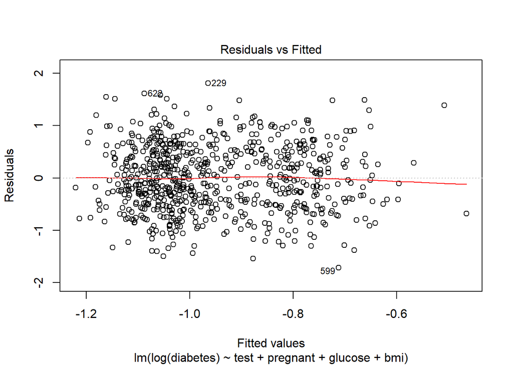

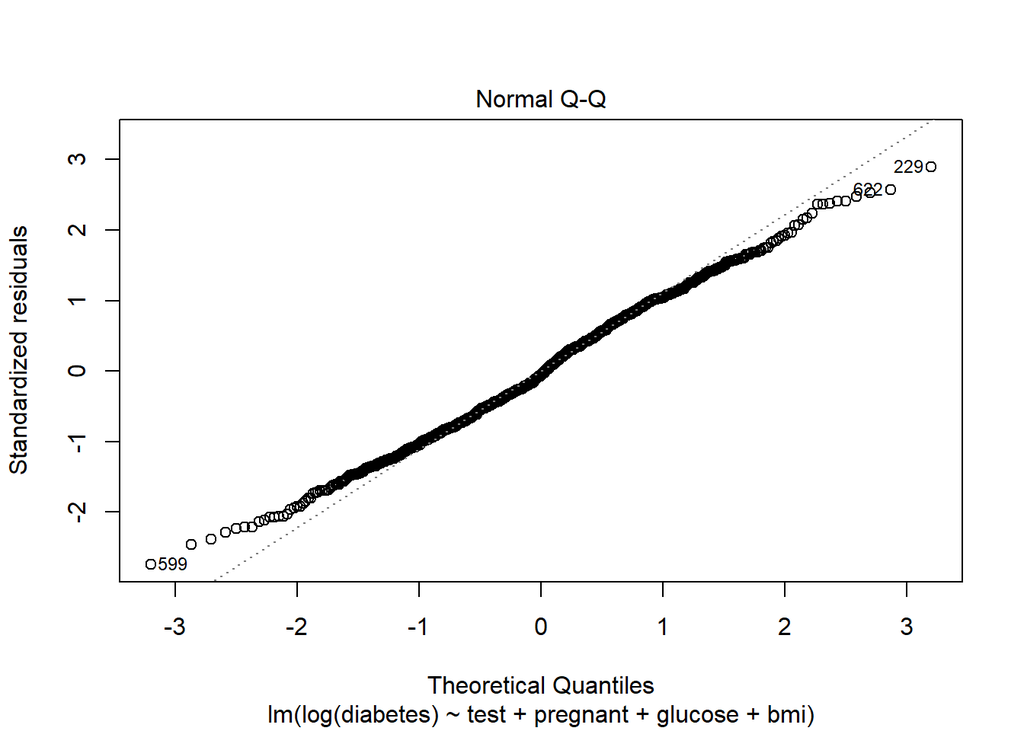

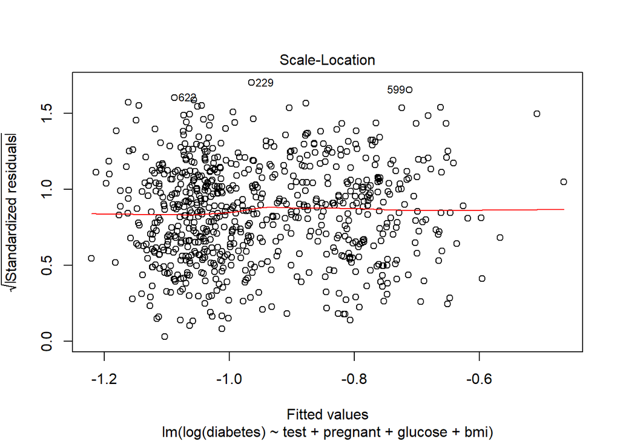

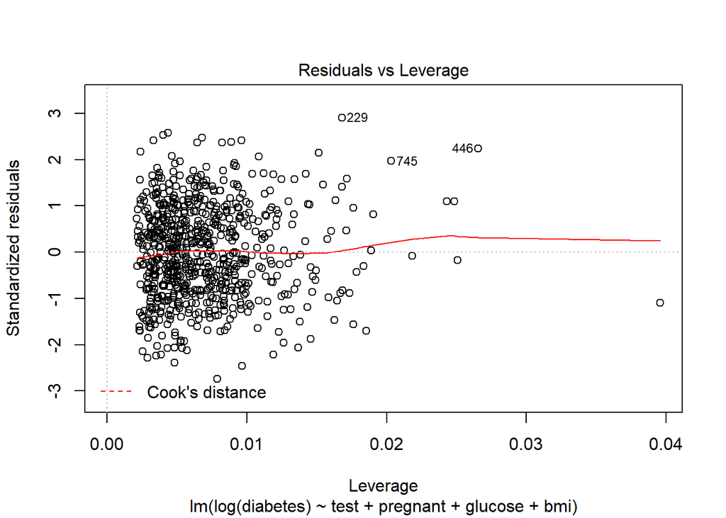

```r
plot(g1)
```

```r
  ActualValues<-g1$model$`log(diabetes)`
  cor(g1$fitted.values,ActualValues)
```

```
## [1] 0.2188014
```

3. What is the R2 for the g1-model? What does R2 mean for the fitted model? Is it good or bad? Explain.

```r
summary(g1)$r.squared
```

```
## [1] 0.04787405
```

The R Square value of g1 model is .047.

It is calculate as R-squared = Explained variation / Total variation

R-squared is always between 0 and 100%

4. Theoretically, what is the relation between the R2 and the Pearson correlation (actual-values vs fitted-values)? Does the relation hold for the computed values of the g1-model? If not, why not?
5. R2 is baically squared correlation coefficient. In linear least squares regression with an estimated intercept term, R2 equals the square of the Pearson correlation coefficient between the observed and modeled (predicted) data values of the dependent variable.The relation hold true for the given model when using approximation.

# 6. F-Test of Model Utility (8 points)

Perform the F-Test of the Utility of model g1.

1. What is the Null Hypothesis? a.Null Hypothesis is the assumption which says that the variable does not predict the response. In other words, the co-efficient of that variable is equal to 0.

For g1 model, the equation is :

Y(Log(Diabetes))= a + b*X(test) + c*X(Pregnant) + d*X(glucose)+e*X(bmi)

Null Hypothesis for X(Test): H(0): b=0 Null Hypothesis for X(Pregnant): H(1): c=0 Null Hypothesis for X(Glucose): H(2): d=0 Null Hypothesis for X(BMI): H(3): e=0

```r
summary(g1)
```

```
##
## Call:
## lm(formula = log(diabetes) ~ test + pregnant + glucose + bmi,
##     data = pima)
##
## Residuals:
##      Min       1Q   Median       3Q      Max
## -1.71884 -0.46622 -0.03373  0.47313  1.81007
##
## Coefficients:
##                Estimate Std. Error t value Pr(>|t|)
## (Intercept)  -1.3037626  0.1459210  -8.935  < 2e-16 ***
## testPositive  0.2246114  0.0589747   3.809 0.000152 ***
## pregnant     -0.0125760  0.0071567  -1.757 0.079303 .
## glucose       0.0004215  0.0008762   0.481 0.630675
## bmi           0.0083489  0.0035818   2.331 0.020033 *
## ---
## Signif. codes:  0 '***' 0.001 '**' 0.01 '*' 0.05 '.' 0.1 ' ' 1
##
## Residual standard error: 0.6291 on 719 degrees of freedom
## Multiple R-squared:  0.04787,    Adjusted R-squared:  0.04258
## F-statistic: 9.038 on 4 and 719 DF,  p-value: 3.99e-07
```

For testing of null hypothesis we check the p-value. If p-value>.05 then null hypothesis is accepted.

We can see that p-value of glucose and pregnant is greater than .05 so we put the co-efficients of both the variable as 0.

The below hypothesis holds true Null Hypothesis for X(Pregnant): H(1): c=0 Null Hypothesis for X(Glucose): H(2): d=0 New equation will be: Y(Log(Diabetes))= a + b*X(test)+e*X(bmi)

2. What is the Alternative Hypothesis?
3. Alernative Hypothesis states that the variable predicts the response. In other words, the coefficients of that varibale is not equal to zero.

Alternative Hypothesis for X(Test): A(0): b!=0 Alternative Hypothesis for X(bmi): A(3): e!=0

We can see that p-value of Test and BMI is less than .05 so both these variables are higly significant in predicting the model.

3. What are the appropriate degrees of freedom to use for the F-distribution?
4. The correct approach is to use p-1 in the numerator (degrees of freedom of the model) and n-p in the denominator (degrees of freedom of the redidual), where p is the number of predictors and n is the number of observations. The sum of these two numbers gives the total degrees of freedom, i.e. n-1

```r
anova(g1)
```

```
## Analysis of Variance Table
##
## Response: log(diabetes)
##            Df  Sum Sq Mean Sq F value    Pr(>F)
## test        1  10.555 10.5549 26.6681 3.131e-07 ***
## pregnant    1   1.407  1.4069  3.5546   0.05978 .
## glucose     1   0.196  0.1964  0.4963   0.48137
## bmi         1   2.150  2.1504  5.4332   0.02003 *
## Residuals 719 284.570  0.3958
## ---
## Signif. codes:  0 '***' 0.001 '**' 0.01 '*' 0.05 '.' 0.1 ' ' 1
```

We can verify the above result from anova table as well.

```r
lwr <- qf(0, 760, g1$df.residual)
upr <- qf(0.95, 760, g1$df.residual)
c(lwr, upr)
```

```
## [1] 0.000000 1.128868
```

So if the F-value falls outside this interval, we could decide that null Hypothesis H(1) and H(2) is false.

Here are two Decision Rules based on the F distribution for our case using the pima dataset: Risk: a=0.05 Rule: If F(1)> 1.12 reject H(1) Risk: a=0.05 Rule: If F(2)> 1.12 reject H(2)

where f1 <- The F-value of pregnant variable f2 <- The F-value of glucose variable H1 <- Null Hypothesis for pregnant variable h2 <- Null Hypothesis for glucose variable.

To see the f-value we use the anova() function:

```r
anova(g1)
```

```
## Analysis of Variance Table
##
## Response: log(diabetes)
##            Df  Sum Sq Mean Sq F value    Pr(>F)
## test        1  10.555 10.5549 26.6681 3.131e-07 ***
## pregnant    1   1.407  1.4069  3.5546   0.05978 .
## glucose     1   0.196  0.1964  0.4963   0.48137
## bmi         1   2.150  2.1504  5.4332   0.02003 *
## Residuals 719 284.570  0.3958
## ---
## Signif. codes:  0 '***' 0.001 '**' 0.01 '*' 0.05 '.' 0.1 ' ' 1
```

8. What is the conclusion of the test with risk a=0.05 using the P-value?

```r
lwrpf <- pf(0, 760, g1$df.residual)
uprpf <- pf(0.95, 760, g1$df.residual)
c(lwrpf, uprpf)
```

```
## [1] 0.0000000 0.2426725
```

where f1 <- The F-value of pregnant variable f2 <- The F-value of glucose variable H1 <- Null Hypothesis for pregnant variable h2 <- Null Hypothesis for glucose variable.

To see the p-value we use the anova() function:

```r
anova(g1)
```

```
## Analysis of Variance Table
##
## Response: log(diabetes)
##            Df  Sum Sq Mean Sq F value    Pr(>F)
## test        1  10.555 10.5549 26.6681 3.131e-07 ***
## pregnant    1   1.407  1.4069  3.5546   0.05978 .
## glucose     1   0.196  0.1964  0.4963   0.48137
## bmi         1   2.150  2.1504  5.4332   0.02003 *
## Residuals 719 284.570  0.3958
## ---
## Signif. codes:  0 '***' 0.001 '**' 0.01 '*' 0.05 '.' 0.1 ' ' 1
```